# NVIDIA Stock Analysis

Joshua Agbroko

# *Overview*

This project analyzes NVIDIA’s stock performance and compares it to the S&P 500 benchmark using R and Python(reticulate). The objective is to determine whether an equally weighted, long-only trading strategy based on NVIDIA’s relative performance can outperform the S&P 500 index.

```r
library(tidyverse)
library(httr)
library(jsonlite)
```

```r
library(ggplot2)
library(lubridate)
library(TTR)
library(reticulate)
```

```r
# Sourcing python script
source_python("fetch_data.py")

# Fetch NVIDIA (NVDA) stock data
nvda_data <- py$get_stock_data("NVDA")

# Converting to R dataframe
nvda_df <- as.tibble(nvda_data)
# View first few rows
print(head(nvda_df))
```

```
## # A tibble: 6 × 2
##   Date                      close
##   <chr>                     <dbl>
## 1 2020-03-06 00:00:00-05:00  6.63
## 2 2020-03-09 00:00:00-04:00  6.11
## 3 2020-03-10 00:00:00-04:00  6.50
## 4 2020-03-11 00:00:00-04:00  6.14
## 5 2020-03-12 00:00:00-04:00  5.39
## 6 2020-03-13 00:00:00-04:00  6.00
```

# *Exploratory Data Analysis On NVIDIA Stock Data*

```r
# Check structure
print(str(nvda_df))
```

```
## tibble [1,256 × 2] (S3: tbl_df/tbl/data.frame)
##  $ Date : chr [1:1256] "2020-03-06 00:00:00-05:00" "2020-03-09 00:00:00-04:00" "2020-03-10 00:00:00-04:00" "2020-03-11 00:00:00-04:00" ...
##  $ close: num [1:1256] 6.63 6.11 6.5 6.14 5.39 ...
##  - attr(*, "pandas.index")=RangeIndex(start=0, stop=1256, step=1)
## NULL
```

```r
nvda_df$Date <- as.Date(nvda_df$Date)
# Check for missing Values
print(sum(is.na(nvda_df)))
```

```
## [1] 0
```

```r
# Summary statistics
summary(nvda_df)
```

```
##       Date                close
##  Min.   :2020-03-06   Min.   :  4.892
##  1st Qu.:2021-06-03   1st Qu.: 14.223
##  Median :2022-08-31   Median : 22.419
##  Mean   :2022-09-02   Mean   : 42.691
##  3rd Qu.:2023-11-30   3rd Qu.: 48.322
##  Max.   :2025-03-05   Max.   :149.430
```

### Stock Price Trends

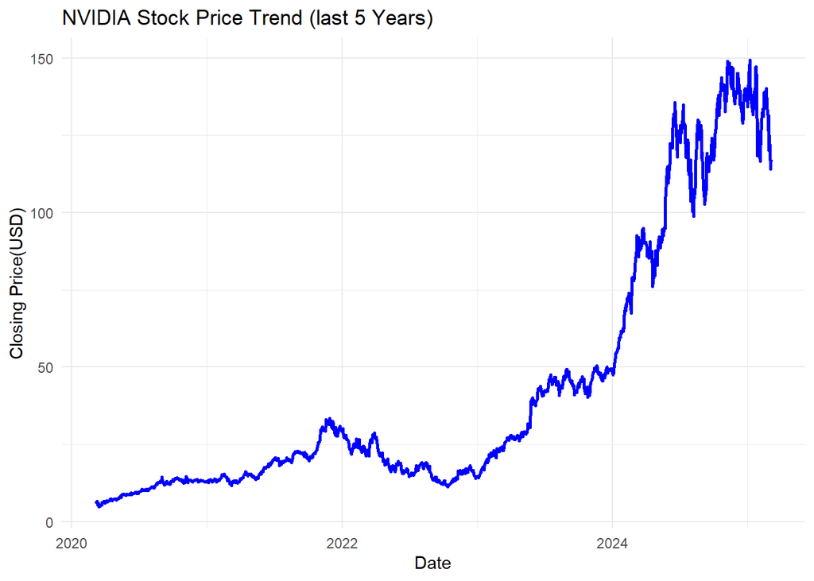

```r
# Line Chart of closing prices
ggplot(nvda_df, aes(x = Date, y = close)) +
  geom_line(color = "blue", size = 1) +
  labs(title = "NVIDIA Stock Price Trend (last 5 Years)",
       x = "Date", y = "Closing Price(USD)") +
  theme_minimal()
```

### Daily Returns

This calculates percentage changes in price daily.

```r
nvda_df <- nvda_df %>%
  arrange(Date) %>%
  mutate(daily_return = (close / lag(close)) - 1)

print(summary(nvda_df$daily_return))
```

```
##      Min.   1st Qu.    Median      Mean   3rd Qu.      Max.      NA's
## -0.184521 -0.016232  0.003291  0.002881  0.022738  0.243697         1
```

```r
head(nvda_df)
```

```
## # A tibble: 6 × 3
##   Date       close daily_return
##   <date>     <dbl>        <dbl>
## 1 2020-03-06  6.63      NA
## 2 2020-03-09  6.11      -0.0774
## 3 2020-03-10  6.50       0.0637
## 4 2020-03-11  6.14      -0.0560
## 5 2020-03-12  5.39      -0.122
## 6 2020-03-13  6.00       0.113
```

### Volatility Analysis

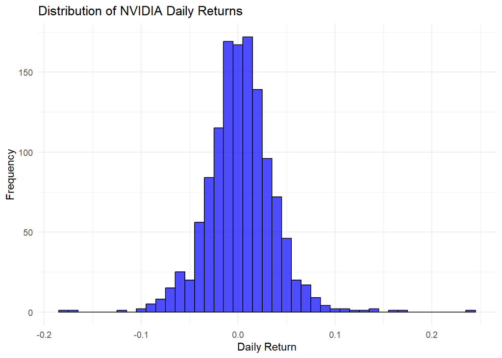

```r
ggplot(nvda_df, aes(x = daily_return)) +
  geom_histogram(binwidth = 0.01, fill = "blue",
                 color = "black", alpha = 0.7) +
  labs(title = "Distribution of NVIDIA Daily Returns",
       x = "Daily Return", y = "Frequency") +
  theme_minimal()
```

### Comparison with the S&P 500

The S&P 500 (Standard & Poor’s 500) is a stock market index benchmark that is used to track the performance of 500 large U.S. companies across various sectors. It is considered a good representation of the U.S. economy and overall stock market performance.

```r
# Fetching S&P  500 ETF data
sp500_data <- py$get_stock_data("SPY")

# converting to R dataframe
sp500_df <- as.tibble(sp500_data)
sp500_df$Date <- as.Date(sp500_df$Date)

print(head(sp500_df))
```

```
## # A tibble: 6 × 2
##   Date       close
##   <date>     <dbl>
## 1 2020-03-06  276.
## 2 2020-03-09  254.
## 3 2020-03-10  267.
## 4 2020-03-11  254.
## 5 2020-03-12  230.
## 6 2020-03-13  250.
```

```r
# Calc. S&P 500 daily returns
sp500_df <- sp500_df %>%
  arrange(Date) %>%
  mutate(daily_return = (close / lag(close)) - 1)

# merging both stock datasets on Date
stock_data <- left_join(nvda_df, sp500_df, by = "Date",
                        suffix = c("_nvda", "_sp500"))

# Rem. NA values
stock_data <- na.omit(stock_data)

stock_data$Date <- as.Date(stock_data$Date)

# Summary of returns
summary(stock_data$daily_return_nvda)
```

```
##      Min.   1st Qu.    Median      Mean   3rd Qu.      Max.
## -0.184521 -0.016232  0.003291  0.002881  0.022738  0.243696
```

```r
summary(stock_data$daily_return_sp500)
```

```
##       Min.    1st Qu.     Median       Mean    3rd Qu.       Max.
## -0.1094236 -0.0051036  0.0009058  0.0006813  0.0073606  0.0906031
```

### Comparing Performance with a T-Test

A t-test checks if NVIDIA’s daily returns are significantly different from S&P 500’s.

```r
t_test_result <- t.test(stock_data$daily_return_nvda,
                        stock_data$daily_return_sp500,
                        alternative = "greater")

print(t_test_result)
```

```
##
##  Welch Two Sample t-test
##
## data:  stock_data$daily_return_nvda and stock_data$daily_return_sp500
## t = 2.1183, df = 1603.6, p-value = 0.01715
## alternative hypothesis: true difference in means is greater than 0
## 95 percent confidence interval:
##  0.0004905229          Inf
## sample estimates:
##    mean of x    mean of y
## 0.0028806397 0.0006813486
```

Since p < 0.05, we reject the null hypothesis, meaning NVIDIA’s mean returns are significantly greater than the S&P 500’s. The confidence interval suggests that even in the worst-case scenario, NVIDIA still uotperforms the S&P 500 on average.

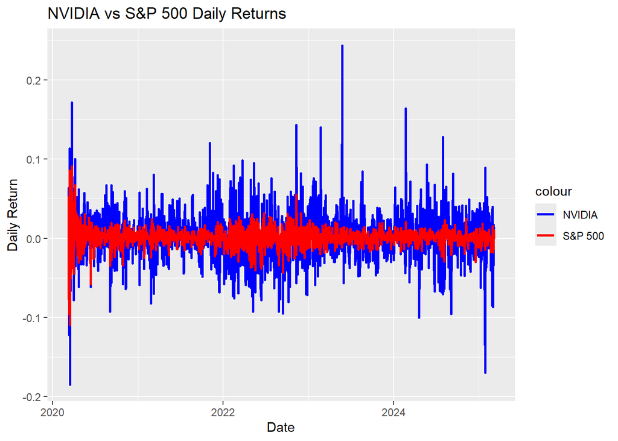

```r
# line plot of NVIDIA vs S&P 500 Returns
ggplot(stock_data, aes(x = Date)) +
  geom_line(aes(y = daily_return_nvda, color = "NVIDIA"), size = 1) +
  geom_line(aes(y = daily_return_sp500, color = "S&P 500"), size = 1) +
  labs(title = "NVIDIA vs S&P 500 Daily Returns",
       x = "Date", y = "Daily Return") +
  scale_color_manual(values = c("NVIDIA" = "blue", "S&P 500" = "red")) +
  theme_gray()
```

This visually compares NVIDIA’s performance with the market

## Implementating a Simple Trading Strategy

We will - Define a trading rule: invest i NVIDIA only if its return is greater than S&P 500 on a given day - Track portfolio performance over time - Compare results to simply holding the S&P 500

### Define the Trading Rule

We create a binary investment signal: - 1(Invest in NVIDIA) -> If daily_return_nvda > daily_return_sp500. - 0(Stay in cash) -> Otherwise.

```r
# adding  atrading signal column (1 - invest, 0 = no investment)
stock_data <- stock_data %>%
  mutate(trade_signal = ifelse(daily_return_nvda > daily_return_sp500, 1, 0))
# Check
head(stock_data)
```

```
## # A tibble: 6 × 6
##   Date       close_nvda daily_return_nvda close_sp500 daily_return_sp500
##   <date>          <dbl>             <dbl>       <dbl>              <dbl>
## 1 2020-03-09       6.11           -0.0774        254.            -0.0781
## 2 2020-03-10       6.50            0.0637        267.             0.0517
## 3 2020-03-11       6.14           -0.0560        254.            -0.0487
## 4 2020-03-12       5.39           -0.122         230.            -0.0957
## 5 2020-03-13       6.00            0.113         250.             0.0855
## 6 2020-03-16       4.89           -0.185         222.            -0.109
## # ℹ 1 more variable: trade_signal <dbl>
```

This identifies the dqays when we invest in NVIDIA.

### Calculating portfolio returns

We assume an equally weighted long-only portfolio and calculate cumulative returns.

```r
# Compute portfolio returns
stock_data <- stock_data %>%
  mutate(portfolio_return = trade_signal * daily_return_nvda)

# Compute cumulative returns
stock_data <- stock_data %>%
  mutate(cumulative_portfolio = cumprod(1 + portfolio_return),
         cumulative_sp500 = cumprod(1 + daily_return_sp500))

# Check
tail(stock_data)
```

```
## # A tibble: 6 × 9
##   Date       close_nvda daily_return_nvda close_sp500 daily_return_sp500
##   <date>          <dbl>             <dbl>       <dbl>              <dbl>
## 1 2025-02-26       131.            0.0367        595.           0.000505
## 2 2025-02-27       120.           -0.0848        585.          -0.0160
## 3 2025-02-28       125.            0.0397        594.           0.0156
## 4 2025-03-03       114.           -0.0869        584.          -0.0175
## 5 2025-03-04       116.            0.0169        577.          -0.0118
## 6 2025-03-05       117.            0.0113        583.           0.0107
## # ℹ 4 more variables: trade_signal <dbl>, portfolio_return <dbl>,
## #   cumulative_portfolio <dbl>, cumulative_sp500 <dbl>
```

This tracks how our trading strategy performs compared to the S&P 500.

### Visualizing performance

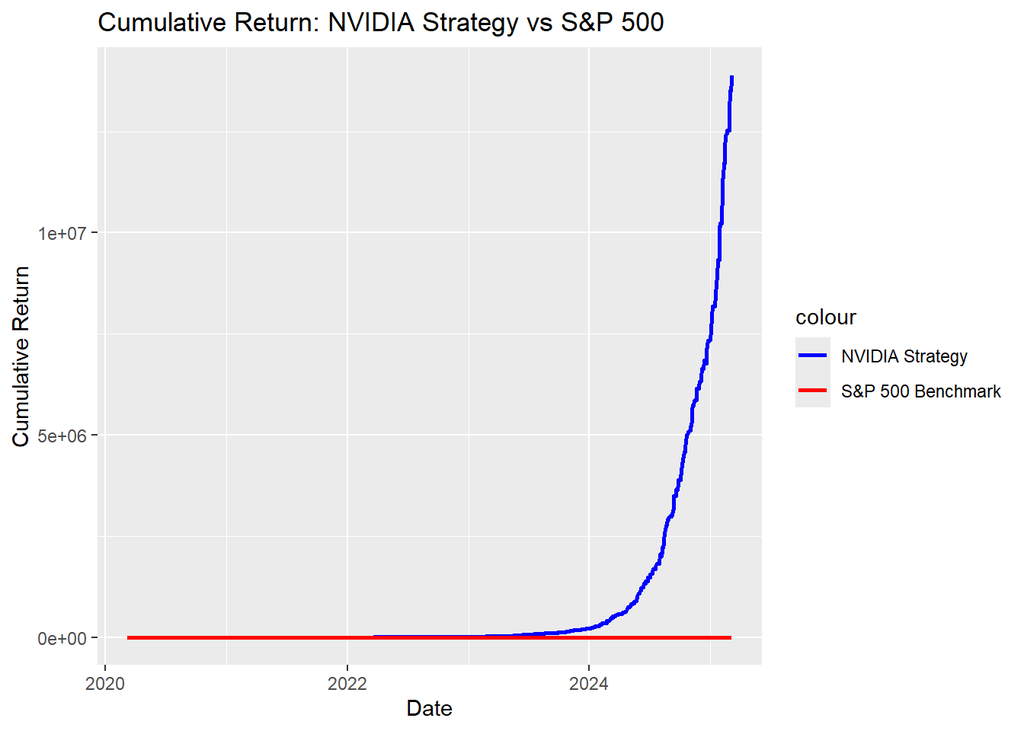

```r
ggplot(stock_data, aes(x = Date)) +
  geom_line(aes(y = cumulative_portfolio, color = "NVIDIA Strategy"), size = 1) +
  geom_line(aes(y = cumulative_sp500, color = "S&P 500 Benchmark"), size = 1) +
  labs(title = "Cumulative Return: NVIDIA Strategy vs S&P 500",
       x = "Date", y = "Cumulative Return") +
  scale_color_manual(values = c("NVIDIA Strategy" = "blue", "S&P 500 Benchmark" = "red")) +
  theme_gray()
```

### Evaluating Strategy Performance

```r
# Computing summary statistics
strategy_mean_return <- mean(stock_data$portfolio_return, na.rm = TRUE)
sp500_mean_return <- mean(stock_data$daily_return_sp500, na.rm = TRUE)

strategy_sd <- sd(stock_data$portfolio_return, na.rm = TRUE)
sp500_sd <- sd(stock_data$daily_return_sp500, na.rm = TRUE)

strategy_sharpe <- strategy_mean_return / strategy_sd
sp500_sharpe <- sp500_mean_return / sp500_sd

# Print
cat("Strategy Mean Return:", strategy_mean_return, "\n")
```

```
## Strategy Mean Return: 0.01343503
```

```r
cat("S&P 500 Mean Return:", sp500_mean_return, "\n")
```

```
## S&P 500 Mean Return: 0.0006813486
```

```r
cat("Strategy Sharpe Ratio:", strategy_sharpe, "\n")
```

```
## Strategy Sharpe Ratio: 0.592922
```

```r
cat("S&P 500 Sharpe Ratio:", sp500_sharpe, "\n")
```

```
## S&P 500 Sharpe Ratio: 0.05249732
```

# *Conclusion*

This project set out to analyze NVIDIA’s sock performance relative to S&P 500 index and evaluate whether an equally weighted, long-only investment strategy in NVIDIA could outperform the benchmark.

Through exploratory data analysis(EDA), return calculations, and statistical testing(t-test)we found that:

## Key Takeaways

- NVIDIA outperformed the S&P 500, making it an attractive stock for active investment.
- Higher returns come with higher risk, requiring risk management strategies such as stop-losses or portfolio diversification.
- Future research could expand this approach to assess whether NVIDIA’s outperformance is consistent or part of a larger market trend.